# Simulation-Based Power Analysis

Part 1.2: Between-subject design and introduction to linear modeling — Handout

Author

Affiliation

Filip Andras, David López-García & David Sánchez Casasola

Centro de Investigación Mente Cerebro y Comportamiento (CIMCYC), Universidad de Granada

Published

26 May 2026

# 1 Why linear models?

Part 1 introduced power analysis using independent-samples t-tests. This part generalises the same logic to the **linear model framework**, which underlies most modern statistical analyses in cognitive science and psycholinguistics.

Linear models are worth learning because they are a flexible framework that goes beyond simple comparisons of means. In particular:

- They handle factorial designs and continuous predictors with the same syntax.
- They extend naturally to **linear mixed-effects models (LMEMs)** for repeated-measures and hierarchical data.
- They handle unbalanced data and missing observations without resorting to listwise deletion.
- They extend again to **generalised linear models (GLMs)** for non-Gaussian outcomes (accuracy, counts, etc.).
- The transition to Bayesian modeling is more straightforward when you already think in terms of linear models.

But the most important reason for this course is pedagogical. Linear models let us walk through a real-life power analysis example where **analytical solutions are not available** and where standard software like G*Power falls short.

A lot of courses end with “for a more complex design use simulations” but never show you how. This course closes that gap.

The flip side of this flexibility is that **the data-generating process is highly specific to your design**. There is no universal recipe — you have to know your data well enough to specify how it is generated.

That responsibility is also the main intellectual payoff. By the time you finish a simulation-based power analysis you understand your design better than any analytical shortcut would have told you.

# 2 Basic terminology

A simple linear model takes the form:

$$y = \beta_0 + \beta_1 \cdot x + \epsilon$$

where:

- **$y$** is the response (dependent) variable.
- **$\beta_0$** is the intercept (*intercepto*).
- **$\beta_1$** is the slope (*pendiente*).
- **$x$** is the predictor (independent variable).
- **$\epsilon$** is the residual error, $\epsilon \sim \text{Normal}(0, \sigma)$.

## 2.1 Mapping to our LDT example

In the lexical-decision-task example from Part 1, the parameters map as follows:

- $\beta_0$ (intercept) = mean response time across both conditions = **725 ms**.
- $\beta_1$ (slope) = difference between conditions = **50 ms**.
- $x$ = condition (lexical frequency), coded as -0.5 / +0.5.

The predicted response times are:

- High lexical frequency: $725 + 50 \cdot (-0.5) = 700$ ms.
- Low lexical frequency: $725 + 50 \cdot (+0.5) = 750$ ms.

In this course we always code the condition as **-0.5 / +0.5** (called *effects coding*). The intercept is the grand mean across both groups and the slope is the **full** difference between conditions. This is convenient for power analysis: the slope parameter directly equals the effect size you are trying to detect, with no factor-of-2 adjustment.

R has other coding schemes (treatment 0/1, sum-to-zero -1/+1) that change the interpretation of intercept and slope, but they all describe the same data and give the same inferential conclusions. We stick with -0.5 / +0.5 throughout.

# 3 Fitting the linear model

With the function from Part 1, we generate one simulated dataset and fit the linear model:

```r
sim_dat <- betwsubj_simdat_ldt()
m0 <- lm(rt ~ cond.cod, sim_dat)
summary(m0)
```

```
Call:
lm(formula = rt ~ cond.cod, data = sim_dat)

Residuals:
    Min      1Q  Median      3Q     Max
-498.60 -128.96  -23.61  171.76  490.02

Coefficients:
            Estimate Std. Error t value      Pr(>|t|)
(Intercept)   763.38      57.94  13.176 0.00000000011 ***
cond.cod      -92.15     115.88  -0.795         0.437
---
Signif. codes:  0 '***' 0.001 '**' 0.01 '*' 0.05 '.' 0.1 ' ' 1

Residual standard error: 259.1 on 18 degrees of freedom
Multiple R-squared:  0.03394,   Adjusted R-squared:  -0.01973
F-statistic: 0.6324 on 1 and 18 DF,  p-value: 0.4368
```

In the summary, the `(Intercept)` row is the estimate of $\beta_0$ (grand mean) and the `cond.cod` row is the estimate of $\beta_1$ (the condition effect). With n = 10 per group, both estimates are noisy — we will see this in the parameter-recovery section below.

# 4 Power analysis with the linear model

The simulation logic from Part 1 works identically — only the analysis step changes. The skeleton:

```r
nsim  <- 10000          # number of simulations
pvals <- rep(NA, nsim)  # vector to store p-values

for (i in 1:nsim) {
                                          # 1. generate a simulated dataset
                                          # 2. fit the linear model
                                          # 3. extract the p-value for the condition effect
}
                                          # 4. count the proportion of p-values less than 0.05
```

And the filled-in version:

```r
nsim  <- 10000
pvals <- rep(NA, nsim)

for (i in 1:nsim) {
  sim_dat  <- betwsubj_simdat_ldt()          # 1. simulate a dataset
  m0       <- lm(rt ~ cond.cod, sim_dat)     # 2. fit the linear model
  pvals[i] <- summary(m0)$coefficients[2, 4] # 3. extract the p-value for the slope
}

round(mean(pvals < 0.05), 3)                 # 4. proportion of p < 0.05
```

```
[1] 0.078
```

The estimated power should match the t-test result from Part 1 (around 7% for n = 10 per group with a 50 ms effect and SD = 200 ms), because the t-test and linear-model test are mathematically equivalent.

# 5 Parameter recovery

A separate question, complementary to power, is whether the model can in principle **recover the true parameter values** under repeated sampling. This is called *parameter recovery*. If the model cannot recover the parameters even with infinite data, the power analysis is moot.

```r
nsim   <- 1000
params <- matrix(rep(NA, nsim * 3), ncol = 3) # 3 parameters: intercept, slope, residual SD

for (i in 1:nsim) {
  sim_dat        <- betwsubj_simdat_ldt()
  m              <- lm(rt ~ cond.cod, sim_dat)
  params[i, 1:2] <- summary(m)$coefficients[, 1] # intercept and slope
  params[i, 3]   <- summary(m)$sigma             # residual SD
}
```

We can visualise the distribution of recovered parameters and overlay the true values (in red) used in the data-generating process:

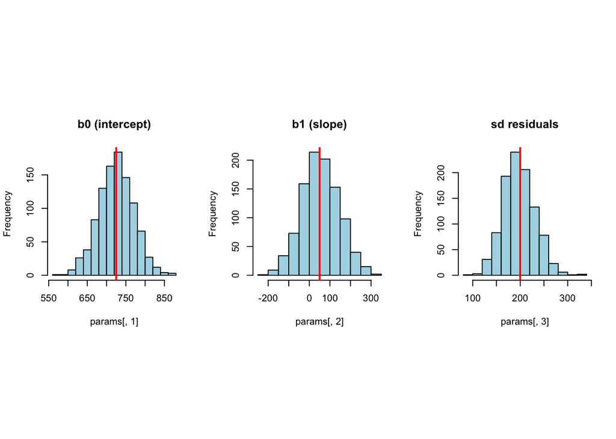

Figure 1: Parameter recovery for the simple linear model with n = 10 per group, 1000 simulations. Red lines show the true values used to generate the data.

The histograms are centred on the true values. The model gives us **accurate estimates of the true parameters under repeated sampling**, although they are noisy (the slope distribution is especially wide because n = 10 is small).

Raising the number of subjects would tighten the distributions — that is precisely the parameter recovery story behind power analysis. Later in the course we will see designs where parameter recovery fails even with large n.

# 6 Summary and next step

So far we have learned to perform power analysis using simulations with the independent-samples t-test and the simple linear model. We have seen that the two approaches give equivalent results for the between-subjects design, and we have introduced parameter recovery as a complementary diagnostic.

The next part of the course generalises this approach to **within-subjects designs**, where each subject contributes data to both conditions and we have to model the dependency between observations explicitly.

This is where the linear-model framework really starts to pay off. Paired t-tests can handle the simplest case, but linear mixed-effects models scale naturally to designs with many repeated measures, items, and random effects.

# 7 Further reading